# COMPSCIX 415.2 Homework 7

ben kimel green

3/18/2019

### Exercise 1

#### Load the train.csv dataset into R. How many observations and columns are there?

There are 1460 observtions and 81 columns.

### Exercise 2

#### Visualize the distribution of SalePrice.

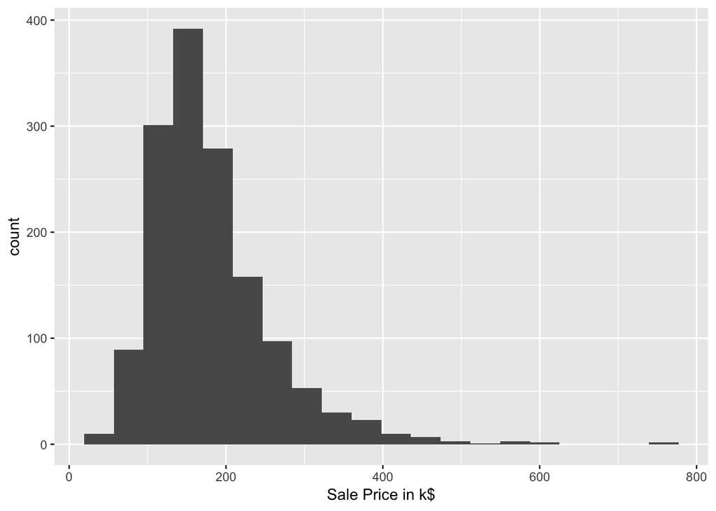

```r
ggplot(housesData)+geom_histogram(aes(SalePrice/1000),bins = 20)+xlab("Sale Price in k$")
```

#### Visualize the covariation between SalePrice and Neighborhood.

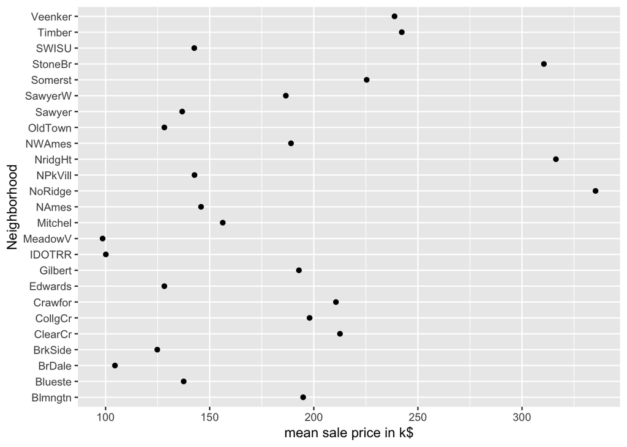

```r
by_hood_mean <- housesData%>%group_by(Neighborhood) %>%summarise(avg = mean(SalePrice/1000))

ggplot(by_hood_mean,aes(x = avg,y = Neighborhood))+geom_point()+xlab("mean sale price in k$")
```

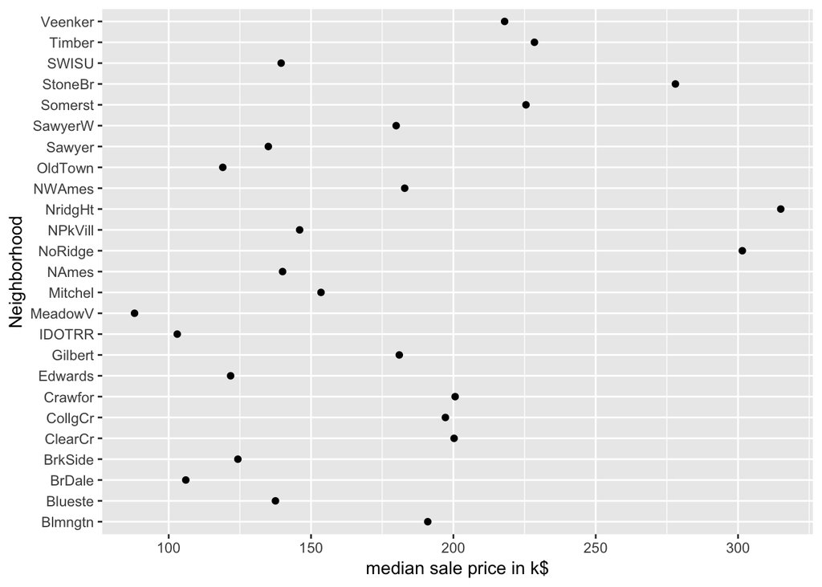

```r
by_hood_median <-housesData%>%group_by(Neighborhood) %>%summarise(med = median(SalePrice/1000))

ggplot(by_hood_median,aes(x = med,y = Neighborhood))+geom_point()+xlab("median sale price in k$")
```

#### Visualize the covariation between SalePrice and OverallQual.

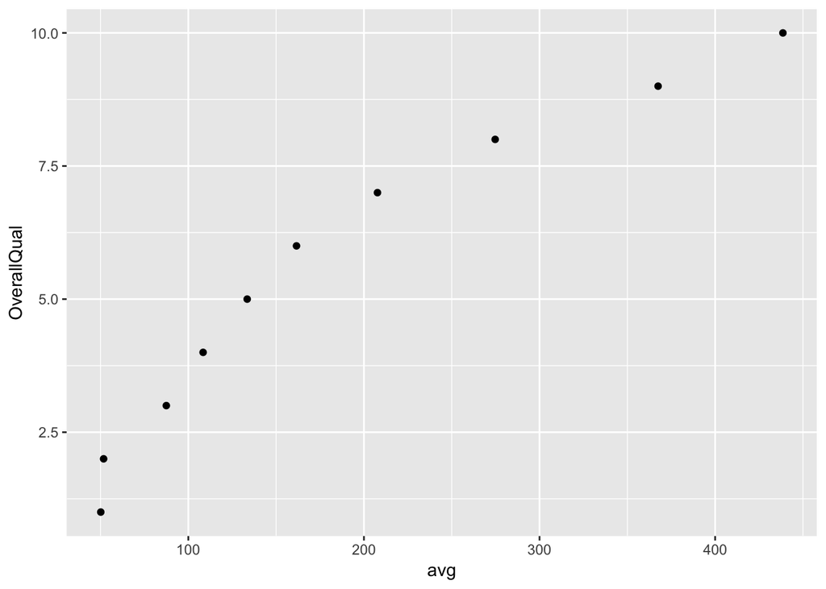

```r
by_quality <- housesData%>%group_by(OverallQual) %>%summarise(avg = mean(SalePrice/1000))

ggplot(by_quality)+geom_point(aes(x = avg, y = OverallQual))
```

### Exercise 3

#### Our target is called `SalePrice`. First, we can fit a simple regression model consisting of only the intercept (the average of SalePrice). Fit the model and then use the `broom` package.

I wasn’t sure what is meant by fitting with the average. I used `1`. I’ll ask you in class.

1. take a look at the coefficient
2. compare the coefficient to the average value of SalePrice

```r
    mean(housesData$SalePrice)
```

```
## [1] 180921.2
```

```r
    (diam_lm <- lm(formula = SalePrice ~ 1, data = housesData))
```

```
##
## Call:
## lm(formula = SalePrice ~ 1, data = housesData)
##
## Coefficients:
## (Intercept)
##      180921
```

3. take a look at the R-squared. (in code below)

```r
  tidy(diam_lm)
```

```
## # A tibble: 1 x 5
##   term        estimate std.error statistic p.value
##   <chr>          <dbl>     <dbl>     <dbl>   <dbl>
## 1 (Intercept)  180921.     2079.      87.0       0
```

```r
  glance(diam_lm)
```

```
## # A tibble: 1 x 11
##   r.squared adj.r.squared  sigma statistic p.value    df  logLik    AIC
##       <dbl>         <dbl>  <dbl>     <dbl>   <dbl> <int>   <dbl>  <dbl>
## 1         0             0 79443.        NA      NA     1 -18544. 37092.
## # … with 3 more variables: BIC <dbl>, deviance <dbl>, df.residual <int>
```

## Exercise 4

#### Fit a linear regression model using `GrLivArea`, `OverallQual`, and `Neighborhood` as the features.

```r
(diam_lm <- lm(formula = SalePrice ~ GrLivArea + OverallQual+ Neighborhood, data = housesData))
```

```
##
## Call:
## lm(formula = SalePrice ~ GrLivArea + OverallQual + Neighborhood,
##     data = housesData)
##
## Coefficients:
##         (Intercept)            GrLivArea          OverallQual
##           -34829.24                55.56             20951.42
## NeighborhoodBlueste   NeighborhoodBrDale  NeighborhoodBrkSide
##           -30752.88            -43358.88            -13025.45
## NeighborhoodClearCr  NeighborhoodCollgCr  NeighborhoodCrawfor
##            24575.64             11414.31             14444.25
## NeighborhoodEdwards  NeighborhoodGilbert   NeighborhoodIDOTRR
##           -17842.95              -892.88            -28178.99
## NeighborhoodMeadowV  NeighborhoodMitchel    NeighborhoodNAmes
##           -19099.02              2030.61             -4430.10
## NeighborhoodNoRidge  NeighborhoodNPkVill  NeighborhoodNridgHt
##            64642.99            -17807.18             71587.84
##  NeighborhoodNWAmes  NeighborhoodOldTown   NeighborhoodSawyer
##            -4720.66            -32080.88             -1219.38
## NeighborhoodSawyerW  NeighborhoodSomerst  NeighborhoodStoneBr
##              303.10             17766.96             69954.47
##   NeighborhoodSWISU   NeighborhoodTimber  NeighborhoodVeenker
##           -36640.15             29905.81             47106.89
```

#### How would you interpret the coefficients on `GrLivArea` and `OverallQual`?

`GrLivArea` is the square fit of living space above ground. So for each square fit the price goes up by 55.56$. `OverallQual` is a scale of 1-10 for the level of finish of the house. Each grade up on this scale is about 20,951$

#### How would you interpret the coefficient on `NeighborhoodBrkSide`?

In this model House prices in this neighborhood are 13025.45 cheaper the other.

#### Are the features significant?

```r
  tidy(diam_lm)
```

```
## # A tibble: 27 x 5
##    term                estimate std.error statistic  p.value
##    <chr>                  <dbl>     <dbl>     <dbl>    <dbl>
##  1 (Intercept)         -34829.   11541.       -3.02 2.59e- 3
##  2 GrLivArea               55.6      2.50     22.2  2.38e-94
##  3 OverallQual          20951.    1162.       18.0  1.24e-65
##  4 NeighborhoodBlueste -30753.   27697.       -1.11 2.67e- 1
##  5 NeighborhoodBrDale  -43359.   12979.       -3.34 8.57e- 4
##  6 NeighborhoodBrkSide -13025.   10450.       -1.25 2.13e- 1
##  7 NeighborhoodClearCr  24576.   11570.        2.12 3.38e- 2
##  8 NeighborhoodCollgCr  11414.    9497.        1.20 2.30e- 1
##  9 NeighborhoodCrawfor  14444.   10502.        1.38 1.69e- 1
## 10 NeighborhoodEdwards -17843.    9986.       -1.79 7.42e- 2
## # … with 17 more rows
```

```r
  glance(diam_lm)
```

```
## # A tibble: 1 x 11
##   r.squared adj.r.squared  sigma statistic p.value    df  logLik    AIC
##       <dbl>         <dbl>  <dbl>     <dbl>   <dbl> <int>   <dbl>  <dbl>
## 1     0.787         0.783 37009.      203.       0    27 -17416. 34887.
## # … with 3 more variables: BIC <dbl>, deviance <dbl>, df.residual <int>
```

#### Are the features practically significant?

Yes since it makes sense to say a house will cost more money if it’s bigger or has better quality of finish. it also makes sense to say that in a given neighborhood houses are cheaper or more expensive.

#### Is the model a good fit?

I think so.

## Exercise 6

#### Fit a linear model to the simulated data below (use y as the target and x as the feature), and look at the resulting coefficients and R-squared. Rerun it about 5-6 times to generate different simulated datasets. What do you notice about the model’s coefficient on x and the R-squared values?

```r
test_data <- function(){sim1a <- tibble(
  x = rep(1:10, each = 3),
  y = x * 1.5 + 6 + rt(length(x), df = 2)
)

(diam_lm <- lm(formula = y ~ x, data = sim1a))

  glance(diam_lm)
  #tidy(diam_lm)
}

test_data()
```

```
## # A tibble: 1 x 11
##   r.squared adj.r.squared sigma statistic p.value    df logLik   AIC   BIC
##       <dbl>         <dbl> <dbl>     <dbl>   <dbl> <int>  <dbl> <dbl> <dbl>
## 1     0.650         0.637  3.03      52.0 7.54e-8     2  -74.8  156.  160.
## # … with 2 more variables: deviance <dbl>, df.residual <int>
```

```r
test_data()
```

```
## # A tibble: 1 x 11
##   r.squared adj.r.squared sigma statistic  p.value    df logLik   AIC   BIC
##       <dbl>         <dbl> <dbl>     <dbl>    <dbl> <int>  <dbl> <dbl> <dbl>
## 1     0.808         0.802  2.20      118. 1.49e-11     2  -65.2  136.  141.
## # … with 2 more variables: deviance <dbl>, df.residual <int>
```

```r
test_data()
```

```
## # A tibble: 1 x 11
##   r.squared adj.r.squared sigma statistic  p.value    df logLik   AIC   BIC
##       <dbl>         <dbl> <dbl>     <dbl>    <dbl> <int>  <dbl> <dbl> <dbl>
## 1     0.908         0.905  1.23      277. 4.74e-16     2  -47.7  101.  106.
## # … with 2 more variables: deviance <dbl>, df.residual <int>
```

```r
test_data()
```

```
## # A tibble: 1 x 11
##   r.squared adj.r.squared sigma statistic  p.value    df logLik   AIC   BIC
##       <dbl>         <dbl> <dbl>     <dbl>    <dbl> <int>  <dbl> <dbl> <dbl>
## 1     0.969         0.968 0.816      886. 9.69e-23     2  -35.4  76.9  81.1
## # … with 2 more variables: deviance <dbl>, df.residual <int>
```